# Schwefel

## Hybrid genetic algorithm

Let’s see what happens if we activate local search maxing `optim=TRUE`. In the `optimArgs` section we have set that every generation the algorithm performs local search with a probability 0.2. The pressel argument is set to default, indicating that the algorithm tends to select for local search solutions with good fit:

```r
ga.schwef.optim1 <- ga("real-valued",
                       fitness = f.schwef,
                       lower=rep(-500,30), upper=rep(500,30),
                       popSize=200,
                       maxiter=1500, run=300,
                       mutation=gareal_nraMutation, optim=TRUE,
optimArgs = list(method = "L-BFGS-B",
                    poptim = 0.2,
                    pressel = 0.5,
                    control = list(fnscale = -1, maxit = 100)),
seed=1313)

summary(ga.schwef.optim1)
```

```
## ── Genetic Algorithm ───────────────────
##
## GA settings:
## Type                  =  real-valued
## Population size       =  200
## Number of generations =  1500
## Elitism               =  10
## Crossover probability =  0.8
## Mutation probability  =  0.1
## Search domain =
##         x1   x2   x3   x4   x5   x6   x7   x8   x9  x10  ...   x29  x30
## lower -500 -500 -500 -500 -500 -500 -500 -500 -500 -500       -500 -500
## upper  500  500  500  500  500  500  500  500  500  500        500  500
##
## GA results:
## Iterations             = 1104
## Fitness function value = -236.8771
## Solution =
##            x1       x2       x3       x4        x5       x6       x7
## [1,] 420.9687 420.9687 420.9687 420.9687 -302.5249 420.9687 420.9687
##            x8        x9      x10  ...       x29      x30
## [1,] 420.9687 -302.5249 420.9687       420.9687 420.9687
```

We are getting to the same local optimum, although a bit faster.

[figure not shown]

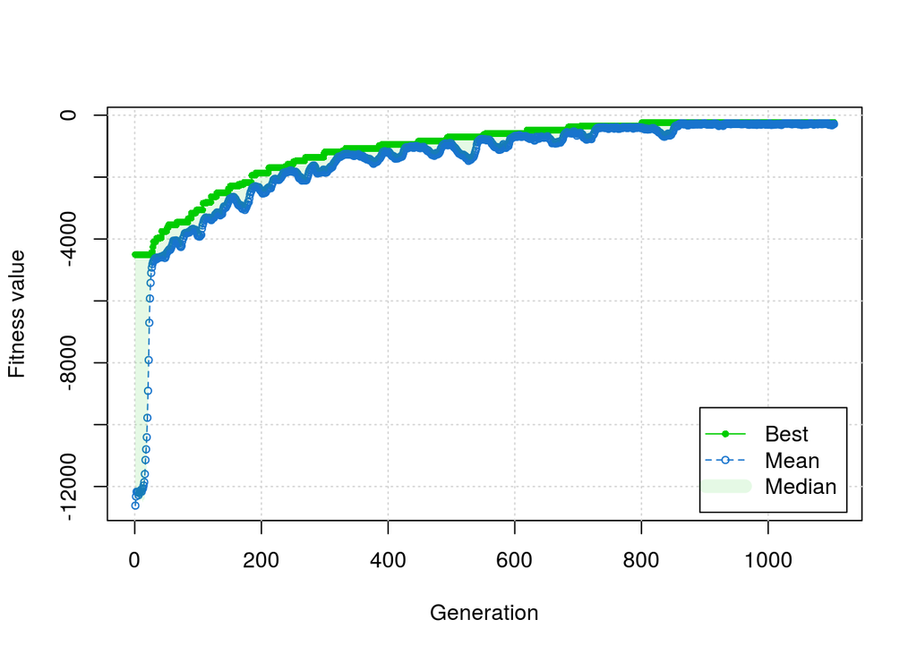